# RCBD analysis by experiment using ASReml

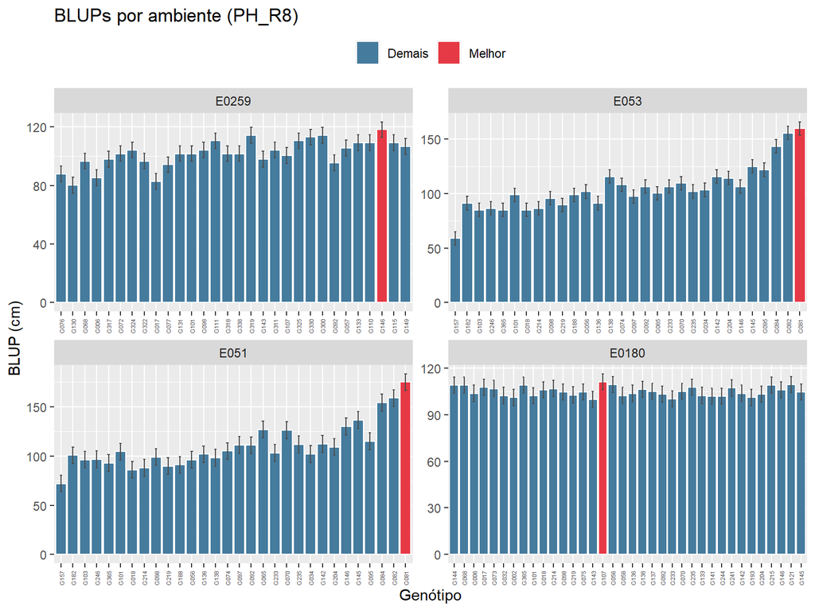

**Grupo 11**

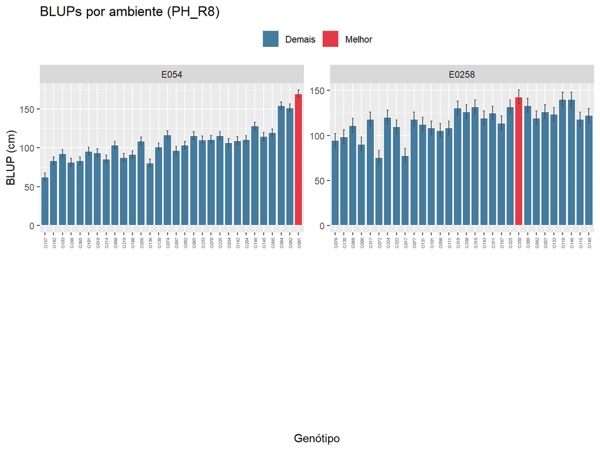

Em alguns painéis, a diferença entre genótipos foi mais evidente, enquanto em outros a variação visual foi menor, indicando maior semelhança entre os materiais. Mesmo com alta herdabilidade para PH_R8, a análise por ambiente mostra que ainda pode haver alteração no desempenho relativo dos genótipos.

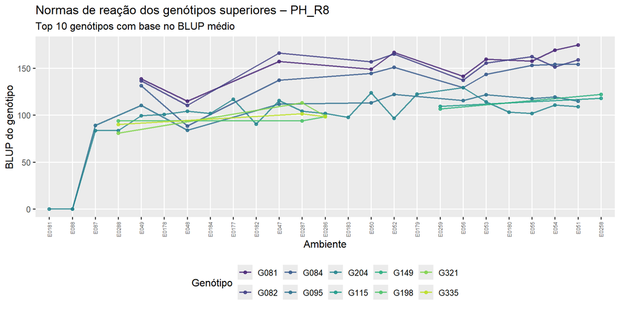

```r
# Normas de reação dos genótipos superiores
# Selecionar os 10 melhores genótipos
top10_gen_ph = rank_ph %>%
  slice_max(BLUP_medio, n = 10) %>%
  pull(Genotipo)

indice_amb_ph = blups_PH_ind %>%
  group_by(Ambiente) %>%
  summarise(indice = mean(BLUP))

dados_norma_ph = blups_PH_ind %>%
  filter(Genotipo %in% top10_gen_ph) %>%
  left_join(indice_amb_ph, by = "Ambiente")

# Ordenar ambientes do menos ao mais favorável
ordem_amb_ph = indice_amb_ph %>%
  arrange(indice) %>%
  pull(Ambiente)

dados_norma_ph$Ambiente = factor(dados_norma_ph$Ambiente, levels = ordem_amb_ph)

ggplot(dados_norma_ph, aes(x = Ambiente, y = BLUP, group = Genotipo, color = Genotipo)) +
  geom_line(linewidth = 0.8, alpha = 0.8) +
  geom_point(size = 1.6, alpha = 0.8) +
  scale_color_viridis_d(option = "D", begin = 0.1, end = 0.9) +
  theme_gray(base_size = 12) +
  theme(
    axis.text.x = element_text(angle = 90, hjust = 1, vjust = 0.5, size = 6),
    panel.grid.minor = element_blank(),
    legend.position = "bottom") +
  labs(
    title = "Normas de reação dos genótipos superiores – PH_R8",
    subtitle = "Top 10 genótipos com base no BLUP médio",
    x = "Ambiente",
    y = "BLUP do genótipo",
    color = "Genótipo")
```

As normas de reação dos genótipos superiores para PH_R8 mostraram o comportamento dos dez materiais com maior BLUP médio ao longo dos ambientes. De modo geral, os genótipos de maior altura, especialmente G081, G082 e G084, mantiveram valores superiores em grande parte dos ambientes avaliados. Embora existam mudanças na magnitude dos BLUPs entre ambientes, as linhas apresentaram comportamento mais consistente do que o observado para produtividade de grãos. Isso indica que a altura de planta possui maior estabilidade relativa e menor sensibilidade ambiental. Ainda assim, a presença de variações entre as linhas mostra que o ambiente também influencia a expressão de PH_R8.

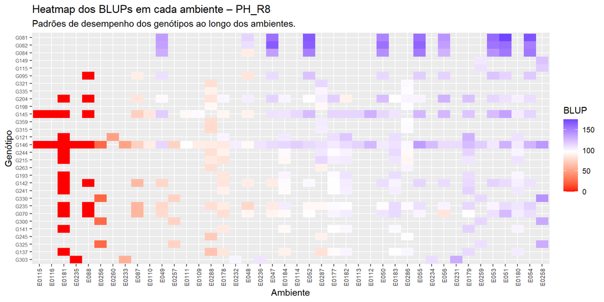

```r
# Top 30 genótipos com maior BLUP médio
top30_ph = blups_PH_ind %>%
  group_by(Genotipo) %>%
  summarise(BLUP_medio = mean(BLUP)) %>%
  slice_max(BLUP_medio, n = 30) %>%
  pull(Genotipo)

heat_data_ph = blups_PH_ind %>%
  filter(Genotipo %in% top30_ph) %>%
  mutate(Genotipo = fct_reorder(Genotipo, BLUP, .fun = mean))

ggplot(heat_data_ph, aes(x = Ambiente, y = Genotipo, fill = BLUP)) +
  geom_tile() +
  scale_fill_gradient2(low = "red", mid = "white", high = "blue", midpoint = mean(heat_data_ph$BLUP)) +
  theme_gray() +
  labs(
    title = "Heatmap dos BLUPs em cada ambiente – PH_R8",
    subtitle = "Padrões de desempenho dos genótipos ao longo dos ambientes.",
    x = "Ambiente",
    y = "Genótipo",
    fill = "BLUP") +
  theme(
    axis.text.y = element_text(size = 6),
    axis.text.x = element_text(angle = 90, hjust = 1, vjust = 0.5, size = 7))
```

O heatmap dos BLUPs para PH_R8 evidenciou padrões de desempenho dos genótipos ao longo dos ambientes. Os tons mais intensos indicam diferenças na altura predita, permitindo identificar genótipos que mantiveram valores elevados em vários ensaios. Em comparação com o heatmap de produtividade, o padrão para PH_R8 foi mais consistente, reforçando a maior estabilidade relativa da altura de planta. Alguns genótipos apresentaram valores altos de BLUP em diversos ambientes, indicando maior regularidade para essa característica. Ainda assim, a presença de variação entre ambientes mostra que a expressão da altura de planta também pode ser influenciada pelas condições ambientais.

## 5.3 Comparação da classificações entre os ensaios

Após as análises individuais por ambiente, foi realizada a comparação das classificações genotípicas entre os ensaios. Para isso, utilizou-se a correlação de Spearman entre os BLUPs dos genótipos em diferentes ambientes. Essa análise permite avaliar se os genótipos mantêm posições semelhantes no ranking ou se há mudança de classificação entre os ambientes. Correlações altas indicam maior estabilidade da classificação genotípica, enquanto correlações baixas sugerem maior influência da interação GxE.

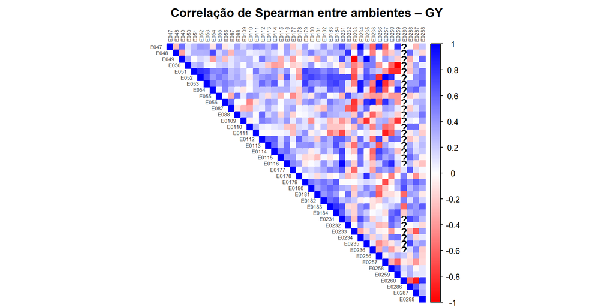

```r
# Formato largo: genótipos nas linhas e ambientes nas colunas
wide_GY = blups_GY_ind %>%
  select(Ambiente, Genotipo, BLUP) %>%
  pivot_wider(names_from = Ambiente, values_from = BLUP)

# Correlação de Spearman
cor_GY = cor(wide_GY %>% select(-Genotipo),
              use = "pairwise.complete.obs",
              method = "spearman")

# round(cor_GY, 2)

corrplot(cor_GY, method = "color", type = "upper",
         tl.cex = 0.5, tl.col = "gray20",
         col = colorRampPalette(c("red", "white", "blue"))(200),
         title = "Correlação de Spearman entre ambientes – GY",
         mar = c(0, 0, 2, 0))
```

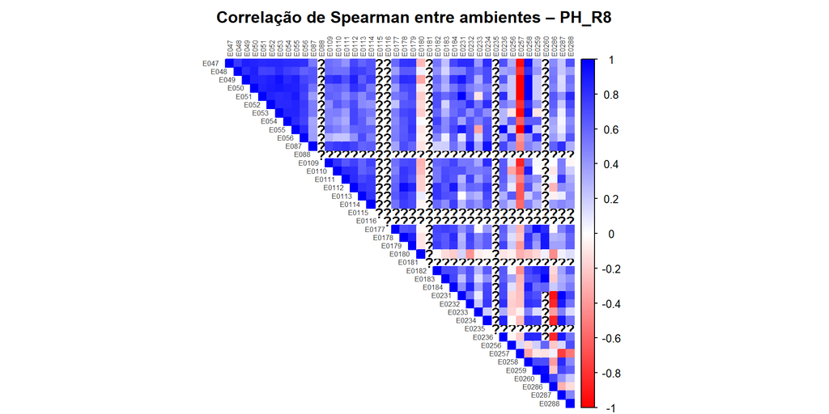

```r
wide_PH = blups_PH_ind %>%
  select(Ambiente, Genotipo, BLUP) %>%
  pivot_wider(names_from = Ambiente, values_from = BLUP)

cor_PH = cor(wide_PH %>% select(-Genotipo),
              use = "pairwise.complete.obs",
              method = "spearman")

#round(cor_PH, 2)

corrplot(cor_PH, method = "color", type = "upper",
         tl.cex = 0.5, tl.col = "gray20",
         col = colorRampPalette(c("red", "white", "blue"))(200),
         title = "Correlação de Spearman entre ambientes – PH_R8",
         mar = c(0, 0, 2, 0))
```

```r
media_cor_GY = mean(cor_GY[upper.tri(cor_GY)], na.rm = TRUE); media_cor_GY
```

```
[1] 0.1496226
```

```r
media_cor_PH = mean(cor_PH[upper.tri(cor_PH)], na.rm = TRUE); media_cor_PH
```

```
[1] 0.4463413
```

A média das correlações de Spearman foi de aproximadamente 0,15 para GY e 0,45 para PH_R8. O valor baixo observado para produtividade de grãos indica pouca concordância na classificação dos genótipos entre os ambientes, reforçando a presença de interação GxE para essa característica. Em termos práticos, isso significa que a seleção de genótipos superiores para GY depende fortemente do ambiente considerado, e que um genótipo bem classificado em um ensaio pode não apresentar o mesmo desempenho relativo em outro. Para PH_R8, a correlação média foi moderada, indicando maior consistência dos rankings entre ambientes. Assim, a altura de planta apresentou maior estabilidade relativa do que a produtividade, embora a correlação não seja alta o suficiente para descartar completamente a influência ambiental sobre a classificação dos genótipos.

## 5.4 Conclusão

A análise individual por ambiente permitiu caracterizar a variabilidade genética, a precisão experimental e o desempenho predito dos genótipos para produtividade de grãos e altura de planta. Para GY, foi detectada variabilidade genética significativa nos ambientes avaliados, mas a característica apresentou forte influência ambiental e baixa estabilidade de classificação entre ensaios. Os genótipos G141, G149, G137, G115 e G002 apresentaram os maiores BLUPs médios para produtividade, sendo candidatos promissores para seleção. Para PH_R8, as estimativas de herdabilidade foram elevadas e os valores de CVe foram menores, indicando maior precisão experimental. Os genótipos G081, G082, G084, G149 e G115 apresentaram os maiores BLUPs médios para altura de planta. A seleção para PH_R8 tende a ser mais confiável do que para GY. De modo geral, os resultados indicam que há variabilidade genética explorável para as duas características avaliadas.